# 1-O‘quv savoli

## **Matplotlib va Seaborn kutubxonalari bilan tanishish**

### **Kirish**

Python dasturlash tilida ma’lumotlarni vizual ko‘rinishda ifodalash eng muhim jarayonlardan biridir. Grafiklar, diagrammalar va chizmalar yordamida murakkab ma’lumotlarni oddiy va tushunarli shaklga keltirish mumkin. Python’da bunday vizualizatsiya asosan ikki asosiy kutubxona orqali amalga oshiriladi:

- **Matplotlib** – asosiy (fundamental) grafik chizish vositasi
- **Seaborn** – Matplotlib ustiga qurilgan, statistik vizualizatsiyani osonlashtiruvchi kutubxona

Ular bir-birini to‘ldiradi, ammo yondashuvlari va imkoniyatlari jihatidan farq qiladi.

# 1. Matplotlib kutubxonasi bilan tanishish

### **1.1. Matplotlib nima?**

Matplotlib — Python dasturlash tilida grafiklar chizish uchun eng mashhur kutubxonalardan biri. U yordamida oddiy chiziqli grafiklardan tortib murakkab uch o‘lchamli (3D) vizualizatsiyalargacha yaratish mumkin.

Vizualizatsiya — ma’lumotni tushunishni yengillashtiradi va natijani boshqalarga aniq ko‘rsatishga imkon beradi.

Matplotlib – Python uchun **eng birinchi, eng katta va asosiy grafik chizish kutubxonasi** (2003 yilda yaratilgan). Bugungi kunda deyarli barcha vizualizatsiya kutubxonalari (Seaborn, Pandas plot, Plotly backend, HoloViews va boshqalar) Matplotlib’ning ichki mexanizmlaridan foydalanadi.

Buni quyidagicha tasavvur qilish mumkin:

> **Matplotlib – barcha grafiklar tayyorlanadigan “asosiy mexanizm”.** Uning ustiga esa boshqa kutubxonalar qulay interfeyslar qo‘shadi.

### **1.2. Matplotlib’ning vazifasi**

Matplotlib quyidagi asosiy vazifalarni bajaradi:

- Grafik oynalar (figure) yaratish
- Koordinata sistemasini boshqarish (axes)
- Chiziqlar, nuqtalar, ustunlar, yoylar, chegara chiziqlarini chizish
- Rasmning har bir elementini boshqarish:
  - rang
  - qalinlik
  - shrifti
  - joylashuvi
  - shaffoflik
- Har qanday grafikni faylga saqlash (PNG, SVG, PDF)

Bu kutubxona **past darajali boshqaruv** beradi, ya’ni foydalanuvchi grafikning har bir detalini aniq sozlashi mumkin.

### **1.3. Matplotlib arxitekturasi**

Matplotlib 2 asosiy komponentdan tashkil topgan:

1. **Figure** – rasm oynasi
2. **Axes** – koordinata sohasi (grafik chiziladigan joy)

Ularning munosabati quyidagicha:

```
Figure (bitta)
 ├─ Axes 1
 ├─ Axes 2
 └─ Axes N
```

Bu tuzilma bitta oynada bir nechta grafiklar chizish imkonini beradi (subplot).

### **1.4. Pyplot modulining roli**

Matplotlib tarkibida eng ko‘p ishlatiladigan modul – **pyplot**.

- `pyplot` – grafiklarni yaratib beruvchi “qo‘lda boshqariladigan panel”
- Matlab dasturiga juda o‘xshash buyruqlar tizimiga ega

Masalan:

- `plt.plot()` – chiziqli grafik
- `plt.scatter()` – nuqtali grafik
- `plt.hist()` – gistogramma
- `plt.bar()` – ustunli grafik
- `plt.title()`, `plt.xlabel()`, `plt.legend()` – rasmni bezatish

Ya’ni **pyplot – grafik chizishni bosqichma-bosqich boshqarish vositasi**.

### **1.5. Matplotlib’ning afzalliklari**

1. **Moslashuvchanlik** – grafiklarning barcha detallarini sozlash mumkin
2. **Professional darajadagi grafiklar** – ilmiy maqola, rasmiy hisobotlar uchun
3. **Ko‘p formatlarni qo‘llab-quvvatlash** – PNG, PDF, SVG, EPS
4. **3D grafiklarni qo‘llashi**
5. **Animatsiya yaratish imkoniyati**

### **1.6. Matplotlib’ning kamchiliklari**

1. Kod ko‘pincha uzun va murakkab ko‘rinadi
2. Kategorik ma’lumotlar bilan ishlash noqulay
3. Statistik vizualizatsiya uchun qo‘shimcha kod kerak bo‘ladi
4. Tayyor chiroyli dizaynlar yo‘q – hammasini qo‘lda sozlash kerak

Shu sababdan Seaborn yaratilgan.

# 2. Seaborn kutubxonasi bilan tanishish

### **2.1. Seaborn nima?**

Seaborn — Python uchun statistik vizualizatsiya kutubxonasi bo‘lib, Matplotlib asosida qurilgan. U:

- chiroyli grafiklar,
- tayyor rang palitralari,
- statistik tahlil grafiklarini

juda kam kod bilan chizishga imkon beradi. Seaborn Pandas bilan yaxshi integratsiyalashganligi sababli DataFrame bilan ishlashda eng qulay kutubxonalardan biridir.

### **2.2. Seaborn’ning vazifasi**

Seaborn quyidagilarni avtomatik qiladi:

- Rang palitralarini tanlash
- Statistik hisob-kitoblar (o‘rtacha, dispersiya, interval)
- Kategorik ma’lumotlarni tasvirlash
- Korrelyatsion munosabatlarni chiqarish
- Pandas DataFrame bilan to‘liq integratsiya

Misol uchun, 3 qatordan iborat ma’lumotdan Seaborn bir necha o‘lchovli grafik yaratib bera oladi.

### **2.3. Seaborn’ning asosiy imkoniyatlari**

Seaborn grafiklari quyidagi guruhlarga bo‘linadi:

#### **1) Statistik taqsimot grafiklari**

- `histplot()` – gistogramma
- `kdeplot()` – zichlik funksiyasi
- `displot()` – kombinatsiyalangan grafik

#### **2) Kategorik grafiklar**

- `barplot()` – guruhlar bo‘yicha o‘rtacha qiymat
- `countplot()` – elementlar soni
- `boxplot()` – quartile taqsimot
- `violinplot()` – intensivlik taqsimoti

#### **3) Bog‘liqlik grafiklari**

- `scatterplot()` – ikkita o‘zgaruvchi orasidagi bog‘liqlik
- `lineplot()` – vaqt/ketma-ketlik bo‘yicha trend
- `regplot()` – regressiya chizig‘i bilan

#### **4) Korrelyatsiya va matritsalar**

- `heatmap()` – bog‘liqliklar issiqlik xaritasi
- `clustermap()` – klasterlash asosidagi matritsa

#### **5) Ko‘p o‘zgaruvchili grafiklar**

- `pairplot()` – barcha juftliklarni bir oynada ko‘rsatish
- `jointplot()` – ikki o‘zgaruvchi + taqsimotlar

### **2.4. Seaborn dizayn (style) tizimi**

Seaborn avtomatik ravishda grafikning dizaynini yaxshilaydi:

- fon
- rang palitralari
- qalinlik
- shriflar
- panjara chiziqlari

Standart `whitegrid` uslubi statistik grafiklar uchun juda qulay.

### **2.5. Seaborn’ning afzalliklari**

1. **Kategorik va statistik ma’lumotlar uchun eng qulay vosita**
2. **Chiroyli tayyor dizaynlar**
3. **Pandas DataFrame bilan bevosita integratsiya**
4. **Minimal kod bilan murakkab vizualizatsiya**
5. **Ranglar avtomatik moslashadi (hue, palette)**
6. **Statistik o‘rtachalarni avtomatik hisoblaydi**

### **2.6. Seaborn’ning cheklovlari**

1. Murakkab grafikni to‘liq moslashtirish kerak bo‘lsa, baribir Matplotlib funksiyalariga murojaat qilishga to‘g‘ri keladi.
2. 3D grafiklar qo‘llab-quvvatlanmaydi.
3. Har bir grafik ortida Matplotlib bor – ba'zan ikki kutubxonaning o‘zaro ta’siri kodni murakkablashtirishi mumkin.

# 3. Matplotlib va Seaborn o‘rtasidagi farqlar

| Band | Matplotlib | Seaborn |
| --- | --- | --- |
| Maqsadi | Asosiy, universal chizish mexanizmi | Statistika va chiroyli vizualizatsiya |
| Arxitekturasi | Past darajali boshqaruv | Matplotlib ustidagi oson interfeys |
| Ma’lumot turi | Sonli grafiklar | Sonli + kategorik + statistik |
| Rangi va dizayni | Qo‘lda sozlanadi | Avtomatik |
| Kod uzunligi | Ko‘p | Qisqa |
| DataFrame bilan ishlash | To‘g‘ridan-to‘g‘ri emas | To‘liq qulay |
| Qaysi holatda ishlatiladi? | Murakkab sozlanadigan grafiklar | Tez, chiroyli va statistik grafiklar |

# 4. Qaysi biri qachon foydalaniladi?

### **Matplotlib qachon kerak?**

- Grafikning har bir elementini nazorat qilish zarur bo‘lsa
- Ilmiy maqolaga maxsus formatdagi rasm kerak bo‘lsa
- 3D grafiklar, animatsiya yoki murakkab subplotlar bo‘lsa
- Dizaynni o‘zingiz boshidan oxirigacha o‘zgartirmoqchi bo‘lsangiz

### **Seaborn qachon kerak?**

- Tezda chiroyli grafik yaratmoqchi bo‘lsangiz
- Statistika elementlari kerak bo‘lsa
- Bo‘limlar, guruhlar, kategoriyalar mavjud bo‘lsa
- DataFrame bilan ishlayotgan bo‘lsangiz
- Korrelyatsiyalarni ko‘rmoqchi bo‘lsangiz

# 5. Umumiy xulosa

- **Matplotlib** – grafiklar “dvigateli”, hamma vizualizatsiya jarayonlarining asosi.
- **Seaborn** – statistik ma’lumotlar uchun qulay, chiroyli interfeys.
- Ular **bir-birini to‘ldiradi**.

# **Matplotlib bilan ma’lumotlarni vizualizatsiya qilish**

[figure not shown]

## **1. Matplotlib o‘rnatish va yuklash**

### **O‘rnatish**

```python
pip install matplotlib
```

### **Kutubxonani chaqirish**

```python
import matplotlib.pyplot as plt
```

**pyplot** — Matplotlib’ning eng ko‘p ishlatiladigan bo‘limi. Grafiklarni juda qisqa kodlar bilan yaratishga yordam beradi.

## **3. Matplotlib Pyplot nima qiladi?**

Pyplot — grafiklar chizishni sodda qiladi. Masalan:

- `plt.plot()` — chiziqli grafik
- `plt.bar()` — ustunli diagramma
- `plt.hist()` — gistogramma
- `plt.scatter()` — nuqtali (scatter) grafik
- `plt.pie()` — doiraviy diagramma

# **4. Matplotlibda asosiy grafik turlari**

Har bir grafik turining vazifasi turlicha. Quyida eng ko‘p uchraydigan grafiklar va ularning sodda misollari keltiriladi.

## **4.1. Chiziqli grafik (Line Chart)**

Vaqt bo‘yicha o‘zgarishni yoki ikki o‘zgaruvchi orasidagi bog‘liqlikni ko‘rsatadi.

### Misol

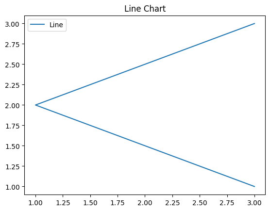

```python
x = [3, 1, 3]
y = [3, 2, 1]

plt.plot(x, y)
plt.title("Line Chart")

plt.legend(["Line"])
plt.show()
```

## **4.2. Ustunli diagramma (Bar Chart)**

Kategoriya qiymatlarini taqqoslash uchun ishlatiladi.

### Misol

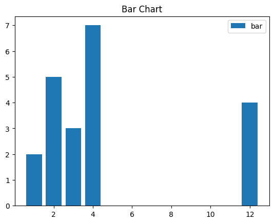

```python
x = [3, 1, 3, 12, 2, 4, 4]
y = [3, 2, 1, 4, 5, 6, 7]

plt.bar(x, y)

plt.title("Bar Chart")

plt.legend(["bar"])
plt.show()
```

## **4.3. Gistogramma (Histogram)**

Ma’lumotning taqsimotini (interval bo‘yicha nechta element tushishini) ko‘rsatadi.

### Misol

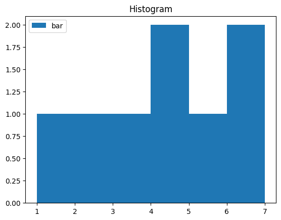

```python
x = [1, 2, 3, 4, 5, 6, 7, 4]

plt.hist(x, bins = [1, 2, 3, 4, 5, 6, 7])

plt.title("Histogram")
plt.legend(["bar"])

plt.show()
```

## **4.4. Scatter Plot (Nuqtali grafik)**

Ikki o‘zgaruvchi orasidagi munosabatni ko‘rsatadi. Klasterlash, trendni ko‘rish uchun ishlatiladi.

### Misol

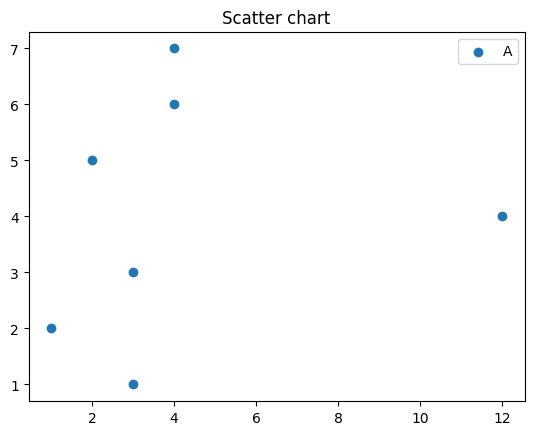

```python
x = [3, 1, 3, 12, 2, 4, 4]
y = [3, 2, 1, 4, 5, 6, 7]
plt.scatter(x, y)

plt.legend("A")

plt.title("Scatter chart")
plt.show()
```

## **4.5. Pie Chart (Doiraviy diagramma)**

Bir butun ichidagi qismlarning ulushini ko‘rsatadi.

### Misol

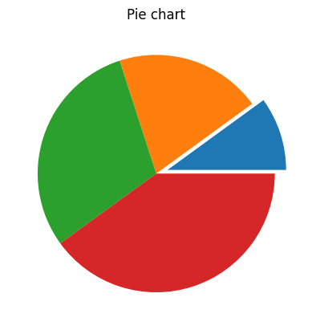

```python
x = [1, 2, 3, 4]

e  =(0.1, 0, 0, 0)

plt.pie(x, explode = e)

plt.title("Pie chart")
plt.show()
```

## **4.6. Stackplot (Yig‘ma maydon grafik)**

Bir nechta kategoriyaning vaqt bo‘yicha umumiy o‘zgarishini ko‘rsatadi.

### Misol

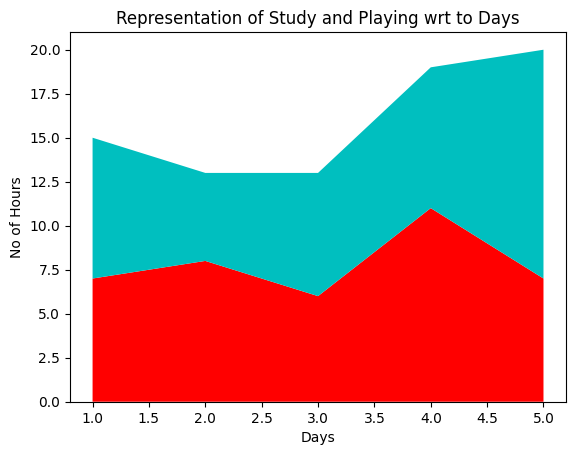

```python
days = [1, 2, 3, 4, 5]
Studying = [7, 8, 6, 11, 7]
playing = [8, 5, 7, 8, 13]

plt.stackplot(days, Studying, playing, colors =['r', 'c'])
plt.xlabel('Days')


plt.ylabel('No of Hours')

plt.title('Representation of Study and \
Playing wrt to Days')

plt.show()
```

## **4.7. Stem Plot (Danak-grafik)**

Diskret ma’lumotni ko‘rsatishda ishlatiladi. Har bir nuqta vertikal chiziq orqali aks ettiriladi.

### Misol

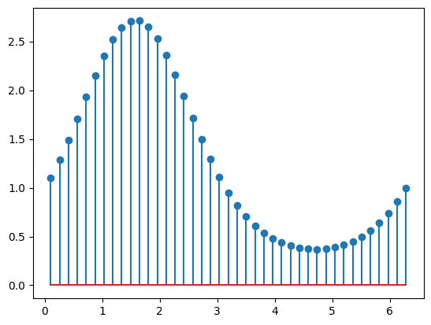

```python
x = np.linspace(0.1, 2 * np.pi, 41)
y = np.exp(np.sin(x))

plt.stem(x, y)
plt.show()
```

## **4.8. Box Plot (Quti-grafik)**

Ma’lumotning median, kvartil va chiqindilarini ko‘rsatadi.

### Misol

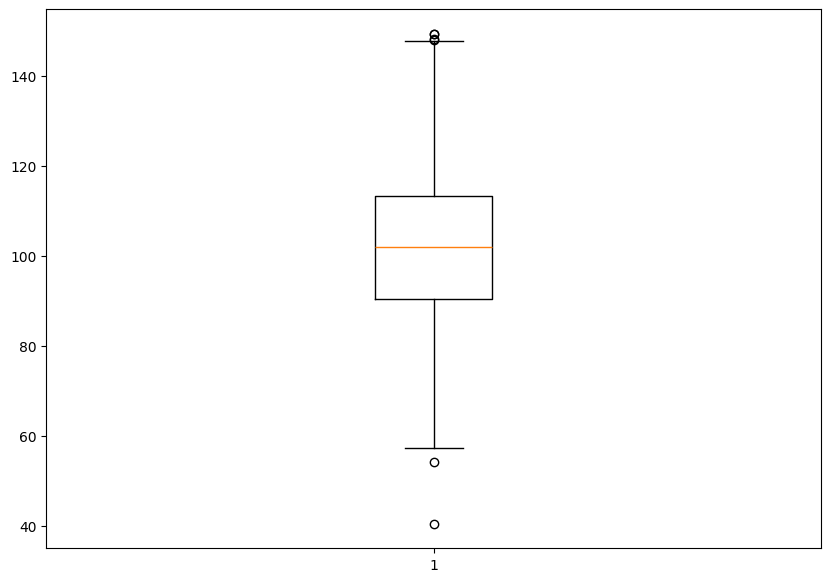

```python
np.random.seed(10)
data = np.random.normal(100, 20, 200)

fig = plt.figure(figsize =(10, 7))

plt.boxplot(data)

plt.show()
```

## **4.9. Error Plot (Xatolik chizig‘i bilan grafik)**

O‘lchovdagi xatolik yoki ishonch oralig‘ini ko‘rsatadi.

### Misol

```
<ErrorbarContainer object of 3 artists>
```

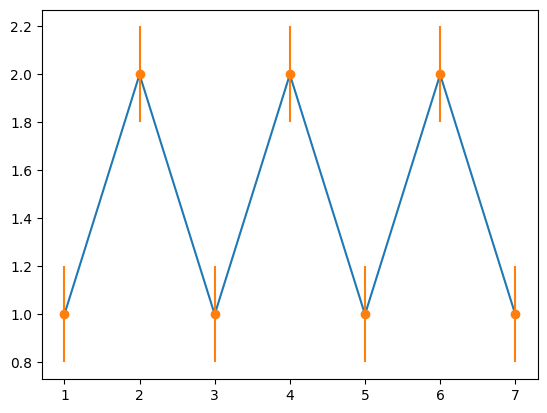

```python
x =[1, 2, 3, 4, 5, 6, 7]
y =[1, 2, 1, 2, 1, 2, 1]

y_error = 0.2

plt.plot(x, y)

plt.errorbar(x, y,yerr = y_error,fmt ='o')
```

## **4.10. Violin Plot (Skripka-grafik)**

Ma’lumot taqsimotini KDE yordamida ko‘rsatadi. Boxplotga o‘xshaydi, lekin taqsimot shakli ham ko‘rinadi.

### Misol

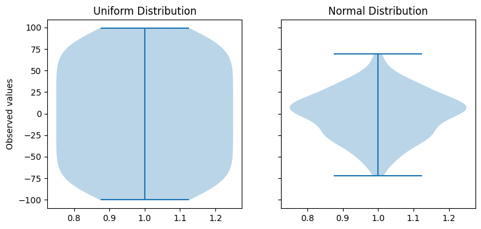

```python
uniform = np.arange(-100, 100)

normal = np.random.normal(size = 100)*30

fig, (ax1, ax2) = plt.subplots(nrows = 1, ncols = 2,
                            figsize =(9, 4),
                            sharey = True)

ax1.set_title('Uniform Distribution')
ax1.set_ylabel('Observed values')
ax1.violinplot(uniform)

ax2.set_title('Normal Distribution')
ax2.violinplot(normal)

plt.show()
```

# **5. Matplotlibda 3D grafika**

3D grafiklar ko‘p o‘lchamli ma’lumotlarni tahlil qilishda yordam beradi.

### 3D o‘qi yaratish

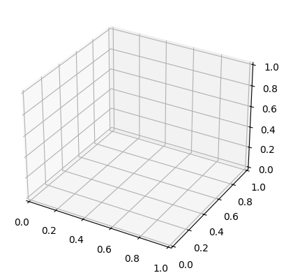

```python
fig = plt.figure()

ax = plt.axes(projection = '3d')
plt.show()
```

### 3D chiziqli grafik

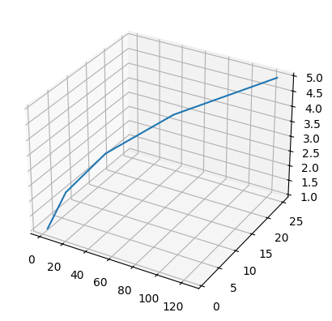

```python
x = [1, 2, 3, 4, 5]
y = [1, 4, 9, 16, 25]
z = [1, 8, 27, 64, 125]

fig = plt.figure()

ax = plt.axes(projection = '3d')
ax.plot3D(z, y, x)
plt.show()
```

# **6. Subplots — bitta sahifada bir nechta grafik**

Bir nechta grafikni yonma-yon yoki ustma-ust joylashtirish uchun ishlatiladi.

### Sintaksis

```
fig, ax = plt.subplots(nrows=1, ncols=1)
```

Misol:

- `plt.subplots(1, 2)` — 1 qator, 2 ustun
- `plt.subplots(2, 2)` — 2×2 tartibda 4 ta grafik

# **Xulosa**

Matplotlib — Python uchun juda kuchli vizualizatsiya vositasi. Unda:

- Chiziqli grafiklar
- Ustunli diagrammalar
- Histogramma
- Scatter plot
- Pie chart
- Box plot
- Violin plot
- 3D grafiklar
- Subplotlar

va yana ko‘plab grafiklar mavjud.

# **Python’da Seaborn yordamida ma’lumotlarni vizualizatsiya qilish**

Quyida turli grafik turlari bo‘yicha sodda misollar keltiriladi.

# **1. Line plot (Chiziqli grafik)**

Chiziqli grafik ikki sonli o‘zgaruvchi orasidagi bog‘liqlikni ko‘rsatadi. Odatda vaqt bo‘yicha o‘zgarishlarni tasvirlashda ishlatiladi. Bir nechta guruhlarni turli chiziqlar orqali solishtirish ham mumkin.

### Sintaksis:

```
sns.lineplot(x=None, y=None, data=None)
```

### Parametrlar:

- **x, y** – sonli kirish qiymatlari (list, array yoki DataFrame ustunlari).
- **data** – DataFrame shaklidagi ma’lumotlar jadvali.

### Misol:

```python
pip install seaborn
```

```
Downloading seaborn-0.13.2-py3-none-any.whl (294 kB)
```

```python
import pandas as pd
import seaborn as sns
```

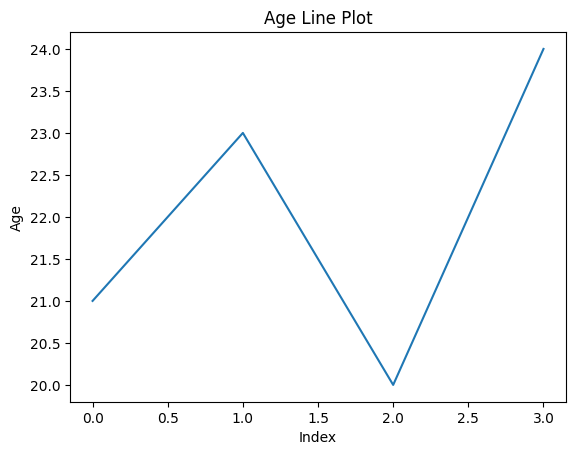

```python
data = {'Name': ['ANSH', 'SAHIL', 'JAYAN', 'ANURAG'], 'Age': [21, 23, 20, 24]}
df = pd.DataFrame(data)

plt.plot(df.index, df['Age'])
plt.xlabel('Index')
plt.ylabel('Age')
plt.title('Age Line Plot')
plt.show()
```

# **2. Scatter Plot (Nuqtali grafik)**

Ikki sonli o‘zgaruvchi orasidagi munosabatni ko‘rsatadi. Korelyatsiya yoki naqshlarni aniqlashga yordam beradi.

### Sintaksis:

```
sns.scatterplot(x=None, y=None, data=None)
```

### Misol:

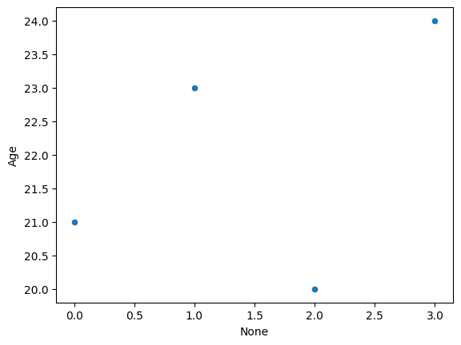

```python
data = {'Name': ['ANSH', 'SAHIL', 'JAYAN', 'ANURAG'], 'Age': [21, 23, 20, 24]}
df = pd.DataFrame(data)

sns.scatterplot(x=df.index, y='Age', data=df)
plt.show()
```

# **3. Box plot (Quti-grafik)**

Numerik ma’lumotning taqsimotini — minimum, maksimum, median va kvartillarni ko‘rsatadi.

### Sintaksis:

```
sns.boxplot(x=None, y=None, hue=None, data=None)
```

### Misol:

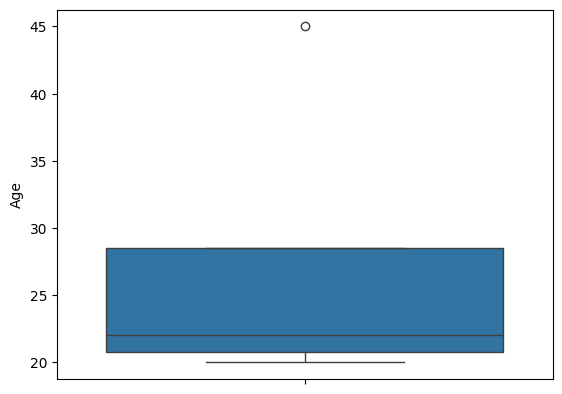

```python
data = {'Name': ['ANSH', 'SAHIL', 'JAYAN', 'ANURAG'], 'Age': [21, 23, 20, 45]}
df = pd.DataFrame(data)

sns.boxplot(y='Age', data=df)
plt.show()
```

# **4. Violin Plot**

Boxplotga o‘xshaydi, ammo taqsimot shaklini (zichlikni) yanada to‘liq ko‘rsatadi.

### Sintaksis:

```
sns.violinplot(x=None, y=None, hue=None, data=None)
```

### Misol:

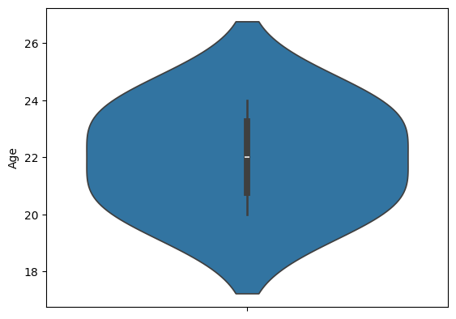

```python
data = {'Name': ['ANSH', 'SAHIL', 'JAYAN', 'ANURAG'], 'Age': [21, 23, 20, 24]}
df = pd.DataFrame(data)

sns.violinplot(y='Age', data=df)
plt.show()
```

# **5. Swarm Plot**

Kategoriya bo‘yicha individual ma’lumot nuqtalarini ustma-ust bo‘lmasdan ko‘rsatadi.

### Sintaksis:

```
sns.swarmplot(x=None, y=None, hue=None, data=None)
```

### Misol:

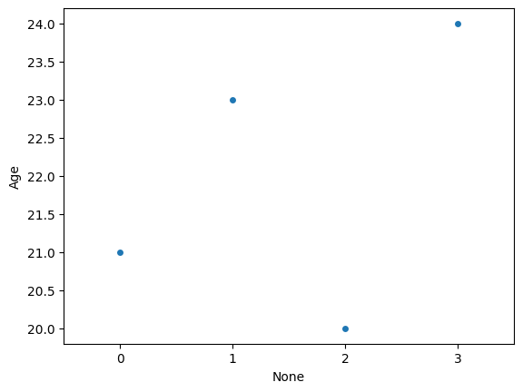

```python
data = {'Name': ['ANSH', 'SAHIL', 'JAYAN', 'ANURAG'], 'Age': [21, 23, 20, 24]}
df = pd.DataFrame(data)

sns.swarmplot(x=df.index, y='Age', data=df)
plt.show()
```

# **6. Bar Plot**

Sonli o‘zgaruvchining o‘rtacha qiymati va uning ishonch oralig‘ini ko‘rsatadi.

### Sintaksis:

```
sns.barplot(x=None, y=None, hue=None, data=None)
```

### Misol:

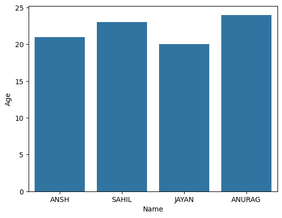

```python
data = {'Name': ['ANSH', 'SAHIL', 'JAYAN', 'ANURAG'], 'Age': [21, 23, 20, 24]}
df = pd.DataFrame(data)

sns.barplot(x='Name', y='Age', data=df)
plt.show()
```

# **7. Point Plot**

Markaziy tendensiya va uning ishonch oralig‘ini nuqta va chiziq orqali ko‘rsatadi.

### Sintaksis:

```
sns.pointplot(x=None, y=None, hue=None, data=None)
```

### Misol:

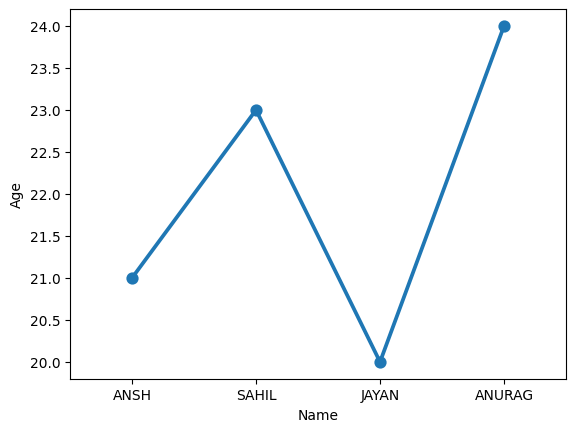

```python
data = {'Name': ['ANSH', 'SAHIL', 'JAYAN', 'ANURAG'],'Age': [21, 23, 20, 24]}
df = pd.DataFrame(data)

sns.pointplot(x='Name', y='Age', data=df)
plt.show()
```

# **8. Count Plot**

Kategoriya nechta marta uchraganini ko‘rsatadi.

### Sintaksis:

```
sns.countplot(x=None, y=None, hue=None, data=None)
```

### Misol:

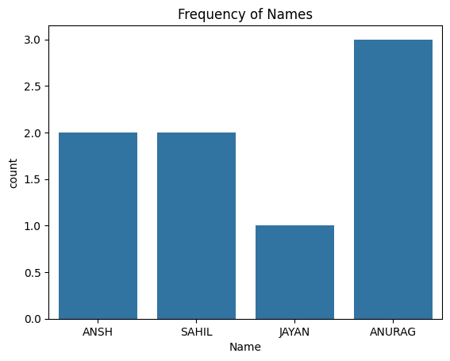

```python
data = {'Name': ['ANSH', 'SAHIL', 'ANSH', 'JAYAN', 'ANURAG', 'ANURAG', 'ANURAG', 'SAHIL']}
df = pd.DataFrame(data)

sns.countplot(x='Name', data=df)
plt.title("Frequency of Names")
plt.show()
```

# **9. KDE Plot (Yadro zichlik grafigi)**

Uzlukli ma’lumotning ehtimollik zichligini aks ettiradi.

### Sintaksis:

```
sns.kdeplot(x=None, *, y=None, vertical=False, palette=None, data=None, **kwargs)
```

### Misol:

```python
!pip install scikit-learn
```

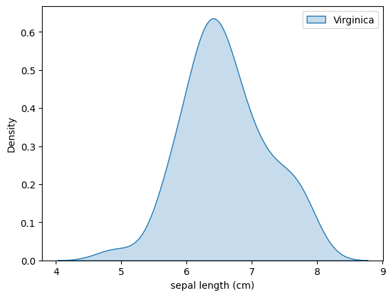

```python
from sklearn.datasets import load_iris

iris = load_iris()
df = pd.DataFrame(iris.data, columns=iris.feature_names)
df['Species'] = iris.target
df['Species'] = df['Species'].map({ 0: 'Setosa', 1: 'Versicolor', 2: 'Virginica'})

sns.kdeplot(data=df[df['Species'] == 'Virginica'], x='sepal length (cm)', fill=True, label='Virginica')
plt.legend()
plt.show()
```

# **Seaborn grafiklarini moslashtirish**

## **1. Sarlavha va o‘qlar nomi qo‘shish**

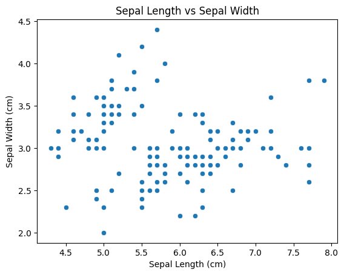

```python
iris = sns.load_dataset('iris')
sns.scatterplot(x='sepal_length', y='sepal_width', data=iris)

# Add plot title and axis labels
plt.title('Sepal Length vs Sepal Width')
plt.xlabel('Sepal Length (cm)')
plt.ylabel('Sepal Width (cm)')
plt.show()
```

## **2. Tayyor uslublar (style)**

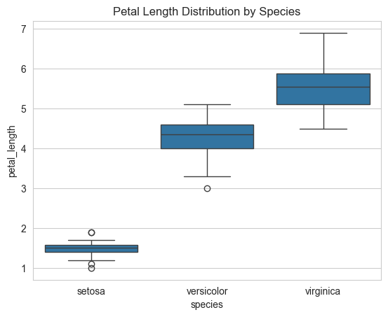

```python
sns.set_style("whitegrid")

sns.boxplot(x='species', y='petal_length', data=sns.load_dataset('iris'))
plt.title('Petal Length Distribution by Species')
plt.show()
```

### **3. Rang palitralarini moslashtirish (Customizing Color Palettes)**

Seaborn grafiklarning ko‘rinishini yanada chiroyli qilish uchun turli rang palitralaridan foydalanishni osonlashtiradi. Siz **"deep"**, **"muted"**, **"bright"** kabi tayyor palitralarni tanlashingiz yoki `sns.color_palette()` yordamida **o‘zingizning maxsus rang palitrangizni** yaratishingiz mumkin. Ranglarni moslashtirish grafikning tushunarli bo‘lishini oshiradi va uni mavzu yoki maqsadga moslashga yordam beradi.

### **a) Tayyor (Built-in) palitradan foydalanish:**

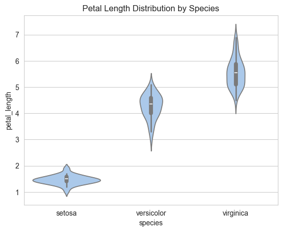

```python
sns.set_palette("pastel")

sns.violinplot(x='species', y='petal_length', data=sns.load_dataset('iris'))
plt.title('Petal Length Distribution by Species')
plt.show()
```

### **b) Maxsus (Custom) rang palitrasidan foydalanish:**

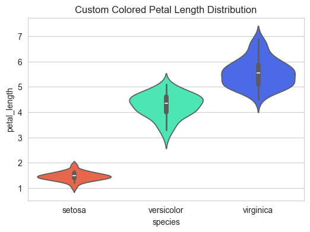

```python
plt.figure(figsize=(6,4))  # kichikroq figura
sns.violinplot(
    x='species',
    y='petal_length',
    hue='species',
    data=iris,
    palette=custom_colors,
    legend=False
)
plt.title('Custom Colored Petal Length Distribution')
plt.show()
```

## **4. Grafik o‘lchamini o‘zgartirish**

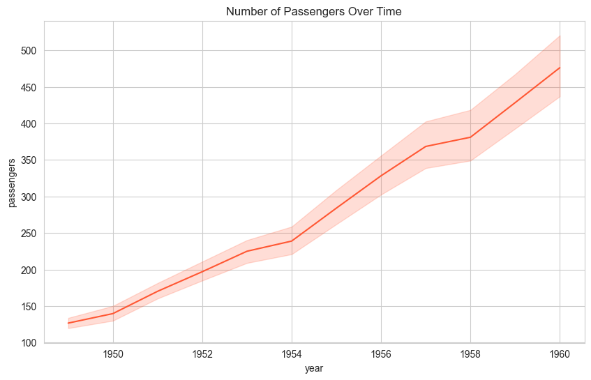

```python
plt.figure(figsize=(10, 6))

sns.lineplot(x='year', y='passengers', data=sns.load_dataset('flights'))
plt.title('Number of Passengers Over Time')
plt.show()
```

## **5. Marker qo‘shish**

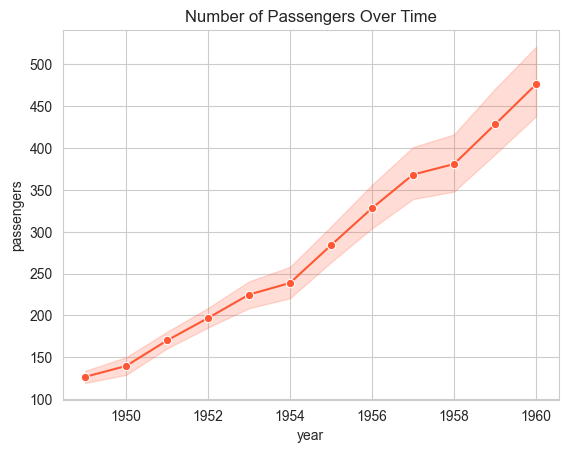

```python
sns.lineplot(x='year', y='passengers', data=sns.load_dataset('flights'), marker='o')
plt.title('Number of Passengers Over Time')
plt.show()
```

# **Seaborn yordamida o‘zaro bog‘liqliklar va naqshlarni vizualizatsiya qilish**

Seaborn kutubxonasi datasetdagi o‘zgaruvchilar orasidagi munosabatlar, taqsimotlar va tendensiyalarni ko‘rsatish uchun turli grafik vositalarni taqdim etadi. Bu vizualizatsiyalar ko‘p o‘zgaruvchili ma’lumotlarda yashirin naqshlar, bog‘liqliklar va korrelyatsiyalarni topishga yordam beradi.

# **1. Pair Plots**

Pair plot ― datasetdagi bir nechta o‘zgaruvchilar orasidagi munosabatlarni ko‘rsatish uchun ishlatiladi. U har bir o‘zgaruvchilar juftligi uchun scatter plot yaratadi va diagonda esa har bir o‘zgaruvchining univariat taqsimoti aks etadi.

Bu ko‘p o‘zgaruvchili datasetlarni o‘rganishda va ularning o‘zaro bog‘liqligini ko‘rishda juda qulay.

### **Sintaksis:**

```
sns.pairplot(data, hue=None)
```

### **Parametrlar:**

- **data** — grafik chiziladigan ma’lumotlar to‘plami
- **hue** — (ixtiyoriy) nuqtalarni rangga ajratuvchi kategorik o‘zgaruvchi

### **Natija:**

Scatter plotlar panjarasi va diagonda taqsimot grafiklari aks etadi.

### **Misol:**

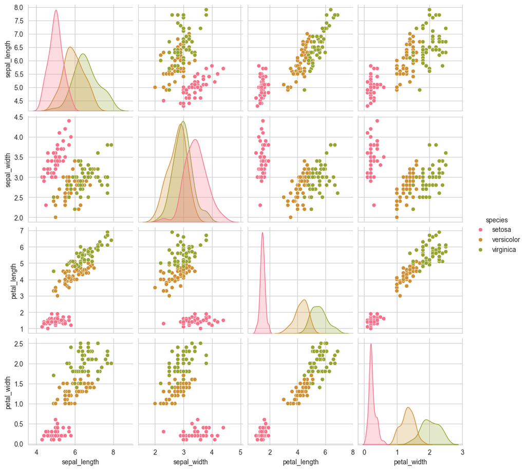

```python
import seaborn as sns
import matplotlib.pyplot as plt

sns.set_style("whitegrid")
custom_palette = sns.color_palette("husl", 8)
sns.set_palette(custom_palette)

data = sns.load_dataset("iris")
sns.pairplot(data, hue="species")
plt.show()
```

# **2. Joint Plots**

Joint plot ― ikkita o‘zgaruvchi orasidagi munosabatni ko‘rsatish uchun scatter plotni, hamda har bir o‘zgaruvchining chekka taqsimotini (histogram yoki KDE) bir grafikda birlashtiradi.

Bu yondashuv ma’lumotning umumiy xarakterini va o‘zgaruvchilar qanday bog‘liqlikka ega ekanligini tezda tushunishga yordam beradi.

### **Sintaksis:**

```
sns.jointplot(x, y, data, kind='scatter')
```

### **Parametrlar:**

- **x, y** — chiziladigan o‘zgaruvchilar
- **data** — dataset
- **kind** — grafik turi: `'scatter'`, `'kde'`, `'reg'` va boshqalar

### **Misol:**

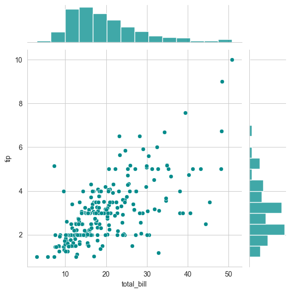

```python
import seaborn as sns
import matplotlib.pyplot as plt

data = sns.load_dataset("tips")
sns.jointplot(x="total_bill", y="tip", data=data, kind="scatter", color="#008B8B")
plt.show()
```

Bu grafik **total_bill** va **tip** orasidagi munosabatni, shuningdek ularning individual taqsimotlarini ko‘rsatadi.

# **3. Grid Plot**

Grid plotlar ― bir nechta subgrafiklarni panjara ko‘rinishida tashkil qilishga imkon beradi. Seaborn’ning **FacetGrid** funksiyasi orqali turli kategoriyalar bo‘yicha guruhlangan grafiklar yaratish mumkin. Bu metod o‘zgaruvchilar ko‘rinishini guruhlar kesimida taqqoslashni osonlashtiradi.

### **Sintaksis:**

```
g = sns.FacetGrid(data, col='column_name', row='row_name')
g.map(sns.scatterplot, 'x', 'y')
```

### **Parametrlar:**

- **data** — ma’lumotlar to‘plami
- **col, row** — panjaraning ustun va qatorlarini belgilovchi kategorik o‘zgaruvchilar
- **sns.scatterplot** — har bir kichik maydonda chiziladigan grafik funksiyasi

### **Misol:**

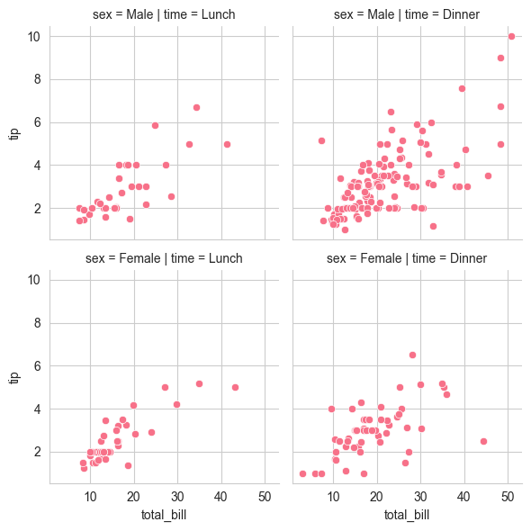

```python
tips = sns.load_dataset("tips")

plot = sns.FacetGrid(tips, col="time", row="sex")
plot.map(sns.scatterplot, "total_bill", "tip")
plt.show()
```

# **Regression Plots: Chiziqli bog‘liqliklarni vizualizatsiya qilish**

Seaborn regressiya chiziqlarini yaratish jarayonini juda soddalashtiradi. Ayniqsa chiziqli regressiya (linear regression) o‘zgaruvchilar orasidagi munosabatni tushunishda, trendlarni topishda va bashorat qilishda muhim ahamiyatga ega.

Seaborn regressiya uchun ikki asosiy funksiyani taqdim etadi:

## **1. regplot()**

- Scatter plot va uning ustiga regressiya chizig‘ini qo‘shadi.
- Kichik va o‘rta datasetlar uchun juda qulay.

## **2. lmplot()**

- Regressiya modelini chizadi,
- Kategoriyalar bo‘yicha facetlarni qo‘llab-quvvatlaydi,
- Bir nechta subplotlar yaratishda qulayroq.

### **Misol:**

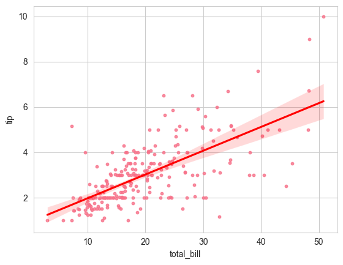

```python
import seaborn as sns
import matplotlib.pyplot as plt

tips = sns.load_dataset('tips')

sns.regplot(x='total_bill', y='tip', data=tips, scatter_kws={'s':10}, line_kws={'color':'red'})
plt.show()
```

Bu regressiya grafigida:

- nuqtalar — ma’lumotlar,
- qizil chiziq — regressiya modeli (trend chizig‘i).

Seaborn’dagi ushbu vizualizatsiya funksiyalari yordamida ma’lumotlarni yanada aniq, tushunarli va tahlil qilishga qulay tarzda ko‘rsatish mumkin.

# **2. Ma’lumotlarni vizualizatsiya qilish texnikalari**

Ma’lumotlarni vizualizatsiya qilish — statistik tahlil, mashinaviy o‘qitish va analitik jarayonlarda eng muhim bosqichlardan biridir. Vizualizatsiya yordamida murakkab ma’lumotlarni sodda shaklda ko‘rish, ularning ichki bog‘liqliklarini aniqlash, tendensiyalarni ko‘rish va qaror qabul qilish jarayonini yengillashtirish mumkin.

Python’da ma’lumotlarni vizualizatsiya qilish uchun asosan **Matplotlib** va **Seaborn** kutubxonalaridan foydalaniladi.

## **1. Chiziqli vizualizatsiya (Line plots)**

Chiziqli grafiklar vaqt bo‘yicha yoki ketma-ket o‘zgaruvchilar orasidagi bog‘liqlikni ko‘rsatadi.

- Trendlarni topish
- O‘zgarish dinamikasini kuzatish
- Ikki yoki bir nechta qiymatlarni solishtirish

**Asosiy funksiyalar:** `plt.plot()`, `sns.lineplot()`

## **2. Nuqtali vizualizatsiya (Scatter plots)**

Ikki o‘zgaruvchi orasidagi bog‘liqlikni ko‘rsatadi.

- Korrelyatsiyani aniqlash
- Klasterlar va naqshlarni topish
- Tarqalishni tahlil qilish

**Asosiy funksiyalar:** `plt.scatter()`, `sns.scatterplot()`

## **3. Ta’riflovchi taqsimot grafiklari**

Bu grafiklar ma’lumotning taqsimoti, markaziy tendensiyasi va farqlanishini ko‘rsatadi.

### **Histogramma**

Ma’lumot intervallar bo‘yicha qanday taqsimlanganini ko‘rsatadi. `plt.hist()`

### **Boxplot (Quti-grafik)**

Minimum, maksimum, median va kvartillarni aks ettiradi. `plt.boxplot()`, `sns.boxplot()`

### **Violinplot**

Boxplotga qo‘shimcha ravishda zichlik (KDE) ham ko‘rsatiladi. `sns.violinplot()`

## **4. Kategoriya bo‘yicha taqqoslash grafiklari**

### **Barplot**

Kategoriya bo‘yicha o‘rtacha qiymatlar yoki chastotalarni ko‘rsatadi. `plt.bar()`, `sns.barplot()`

### **Countplot**

Kategoriya necha marta uchraganini ko‘rsatadi. `sns.countplot()`

### **Pointplot**

Kategoriya bo‘yicha o‘rtacha qiymatlar va ishonch oralig‘ini nuqta sifatida aks ettiradi. `sns.pointplot()`

### **Swarmplot**

Kategoriya ichidagi individual nuqtalarni ustma-ustlashmasdan ko‘rsatadi. `sns.swarmplot()`

## **5. Juftlik vizualizatsiyasi (Pair plots)**

Ko‘p o‘zgaruvchili ma’lumotlar orasidagi umumiy bog‘liqliklarni ko‘rsatadi.

- Har bir juftlik uchun scatter plot
- Diagonal bo‘yicha taqsimot grafigi `sns.pairplot()`

## **6. Qo‘shma vizualizatsiya (Joint plots)**

Bitta grafikda:

- ikki o‘zgaruvchi orasidagi munosabat (scatter)
- har birining taqsimoti (histogram/KDE)

ko‘rsatiladi. `sns.jointplot()`

## **7. FacetGrid (Kategoriyalar bo‘yicha bir nechta grafiklar)**

Biror o‘zgaruvchini boshqa kategoriyalar bo‘yicha taqqoslash uchun sub-grafiklar yaratadi. `sns.FacetGrid()`

## **8. Regressiya grafiklari**

Chiziqli bog‘liqlik va trendlarni aniqlashda ishlatiladi.

- `sns.regplot()` — scatter + regressiya chizig‘i
- `sns.lmplot()` — facetlar bilan regressiya

## **9. Rang palitralari va uslublarni moslashtirish**

Grafiklarni chiroyli, aniq va o‘qish uchun qulay qilishda muhim:

- Stil: `sns.set_style("whitegrid")`
- Rang palitrasi: `sns.set_palette("pastel")`
- Maxsus palitra: `sns.color_palette()`
- Figura o‘lchami: `plt.figure(figsize=(10,6))`

# **Xulosa**

Ma’lumotlarni vizualizatsiya qilish texnikalari — analitik jarayonning ajralmas qismi bo‘lib, ular yordamida ma’lumotdagi bog‘liqliklar, o‘zgarishlar va naqshlar aniq ko‘rinadi. Matplotlib va Seaborn kutubxonalari statistik va analitik grafiklarning keng turini taqdim etadi, bu esa foydalanuvchiga ma’lumotni to‘liq tahlil qilish imkonini beradi.